# Método no paramétrico de análisis

## 08-01 Método no paramétrico de análisis

Los métodos estadísticos converncionales suponen que la distribución de la población sigue una distribución específica (métodos paramétricos), mientras que los métodos no paramétricos se unitilizan cuando no se puede asumir que la distribución de la población sigue una distribución particular.

- Datos ordinales
- Datos categóricos
- Robustez

### Tipos de métodos no paramétricos

#### Inferencia sobre dos poblaciones (para datos no pareados)

- Prueba de Wilcoxon
- Prueba de Mood

#### Inferencia sobre una población

- Prueba de rangos con signo de Wilcoxon
- Prueba de signos

#### Análisis de correlación

#### Análisis de varianza (ANOVA)

- Prueba de Kruskal-Wallis
- Prueba de Friedman
- Coeficiente de concordancia de Kendall

## Preparación de *Python*

```python
from google.colab import drive
drive.mount('/content/drive/')
```

```python
import os

path = os.getcwd()

try:
  os.chdir(path + '/drive/My Drive/QC_Kentei')
except:
  pass

os.getcwd()
```

```
'/content/drive/My Drive/QC_Kentei'
```

```python
import gspread

from google.colab import auth
auth.authenticate_user()

from google.auth import default
creds, _ = default()

gc = gspread.authorize(creds)
```

```python
!pip install japanize-matplotlib
```

```
     ━━━━━━━━━━━━━━━━━━━━━━━━━━━━━━━━━━━━━━━━ 4.1/4.1 MB 37.4 MB/s eta 0:00:00
  Preparing metadata (setup.py) ... done
```

```python
import pandas as pd
import numpy as np

import matplotlib.pyplot as plt
import seaborn as sns
import japanize_matplotlib
```

## 8.1

ある２種類の樹脂材料A、Bの強度に違いがあるかどうか調べるため、表８．４のデータを得た。開発初期の段階ということもあり、分布の形は左右対称であるが、正規分布と比べて分布の裾が長い分布となっているため、ウィルコクスン検定を行い、評価せよ（単位は省略）。

Para investigar si existen diferencias en la resistencia de dos tipos de materiales de resina, A y B, se recopilaron los datos presentados en la tabla 8.4. Dado que el desarrollo se encuentra en una etapa inicial, la distribución es simétrica pero presenta colas más largas en comparación con una distribución normal. Por lo tanto, realiza la prueba de Wilcoxon y evalúa los resultados (las unidades se omiten).

```python
url = "https://docs.google.com/spreadsheets/d/1RkO0VL4WR6cbPBfBEjz693Lo4SdUAoSvRHV491ggXTo/edit?usp=sharing"
ss = gc.open_by_url(url)

# Obtener los datos (como lista)
st = ss.worksheet("Sheet6")
list_of_lists = st.get_all_values()

df = pd.DataFrame.from_records(list_of_lists)
df = df.drop(0)
df = df.T

df.columns = df.iloc[0]
df = df.drop(index=0)

df[["A","B"]] = df[["A","B"]].apply(pd.to_numeric)
data = df.copy()

tabla = df.T
tabla.index.name = "resina"
tabla.to_excel("Data_1/tabla_8.4.xlsx")

print('Tabla 8.4')
tabla
```

```
Tabla 8.4
```

| resina | 1 | 2 | 3 | 4 | 5 | 6 | 7 | 8 | 9 |
| --- | --- | --- | --- | --- | --- | --- | --- | --- | --- |
| A | 60.0 | 50.0 | 51.0 | 42.0 | 55.0 | 46.0 | 49.0 | 52.0 | 43.0 |
| B | 40.0 | 76.0 | 48.0 | 64.0 | 59.0 | 63.0 | 73.0 | 56.0 | NaN |

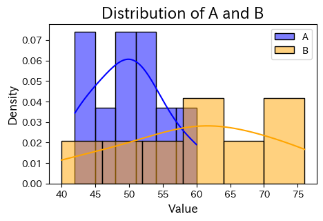

```python
data = data
df = pd.DataFrame(data)

plt.figure(figsize=(5, 3))
sns.histplot(df['A'], kde=True, color='blue', label='A', bins=6, stat="density")
sns.histplot(df['B'], kde=True, color='orange', label='B', bins=6, stat="density")
plt.title('Distribution of A and B', fontsize=16)
plt.xlabel('Value', fontsize=12)
plt.ylabel('Density', fontsize=12)
plt.legend()
plt.show()
```

```python
from scipy.stats import rankdata, mannwhitneyu

data = data
df = pd.DataFrame(data)

combined = pd.concat([df['A'], df['B']])
ranked = combined.rank(method='average')
ranked = ranked.reset_index(drop=True)

df['Rank A'] = ranked[:len(df['A'])].values
df['Rank B'] = ranked[len(df['A']):].values

print("Tabla de datos de rango:")
print(df[['A', 'B', 'Rank A', 'Rank B']].T)

# Data
A = data['A'].to_list()
B = data['B'].to_list()
B = B[:-1]

combined = A + B
ranks = rankdata(combined)  # Calcular los rangos

# 2. Calcular la suma de rangos por grupo
ranks_A = ranks[:len(A)]  # Rango de grupo A
ranks_B = ranks[len(A):]  # Rango de grupo B

T_A = np.sum(ranks_A)  # Suma de rangos del grupo A
T_B = np.sum(ranks_B)  # Suma de rangos del grupo b

# 3. Calcular la estadística de prueba w
W = min(T_A, T_B)

# 4. Prueba de Mann-Whitney U  (Ejectar automáticamente con Scipy)
stat, p_value = mannwhitneyu(A, B, alternative='two-sided')

# Salida de resultados
print("\nSuma de rangos T_A:", T_A)
print("Suma de rangos T_B:", T_B)
print("Estadística de la prueba W:", W)
print("Estadística de la pureba de Mann-Whitney U :", stat)
print("p値:", p_value)

# Tomar una decisión basada en el value p
if p_value < 0.05:
    print("Existe una diferencia estadísticamente significativa entre A y B")
else:
    print("No existe una diferencia estadísticamente significativa entre A y B")
```

```
Tabla de datos de rango:
           1     2     3     4     5     6     7     8     9
0
A       60.0  50.0  51.0  42.0  55.0  46.0  49.0  52.0  43.0
B       40.0  76.0  48.0  64.0  59.0  63.0  73.0  56.0   NaN
Rank A  13.0   7.0   8.0   2.0  10.0   4.0   6.0   9.0   3.0
Rank B   1.0  17.0   5.0  15.0  12.0  14.0  16.0  11.0   NaN

Suma de rangos T_A: 62.0
Suma de rangos T_B: 91.0
Estadística de la prueba W: 62.0
Estadística de la pureba de Mann-Whitney U : 17.0
p値: 0.07445495680789799
No existe una diferencia estadísticamente significativa entre A y B
```

## 08-02 Calidad sensorial

1. Calidad sensorial
- Elementos de calidad que apelan a la sensibilidad humana
2. Método de evaluación sensorial
- Cinco sentidos: Vista, Audición, Olfato, Gusto, Tacto
- Método de prueba de discriminación: Determinar si hay una diferencia entre dos muestras.
- Método de prueba utilizando escalas y categorías: Se utiliza para evaluar el orden de las diferencias, su magnitud, las categorías correspondientes y la clasificación.
- Método de prueba de clasificación o pureba descriptiva: Se utiliza para capturar cualitativa y cuantitativamente las características de una o más propiedades sensoriales.